# homework

Zhang chunxu

2024-12-07

# HW0

## Question

Use knitr to produce at least 3 examples.For each example,texts should mix with figures and/or tables. Better to have mathematical formulas.

### Example 1

graphing functions
$$y=x^2$$

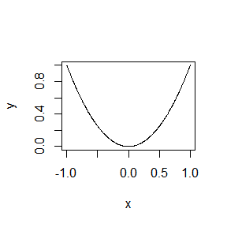

```r
set.seed(0)
GF <- function(f,a,b){
  x <- sort(runif(1000 ,min = a,max = b))
  y <- f(x)
  plot(x,y,type = "l")
}

f1 <- function(x) x^2
GF(f1 ,-1,1)
```

### Example 2

matrix multiplication

```r
A <- matrix(c(1,2,3,4),2,2)
B <- matrix(c(0,1,1,0),2,2)
A%*%B
```

```
##      [,1] [,2]
## [1,]    3    1
## [2,]    4    2
```

### Example 3

calculating $\pi$ using montecarlo

```r
set.seed(0)
N <- 1000
x <- runif(N)
y <- runif(N)
z <- x^2 + y^2
cat("pi =",sum(z<1)/N*4)
```

```
## pi = 3.148
```

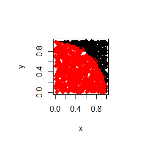

```r
par(pty="s")
plot(x,y,col=ifelse((z) < 1, "red","black"),pch=16)
lx <-seq(from = 0, to = 1,length=N)
lines(lx ,sqrt(1-lx^2))
```

# HW1

## Exercise 3.4

Develop an algorithm to generate random samples from a Rayleigh(σ) distribution. Generate Rayleigh(σ) samples for several choices of σ > 0 and check that the mode of the generated samples is close to the theoretical mode σ (check the histogram).

$$使用逆变换法：\\
f(x)=\frac{x}{\sigma^2}e^{-x^2/(2\sigma^2)},x\geq0,\sigma>0\\
F(x)=1-e^{-x^2/(2\sigma^2)}\\
F^{-1}(x)=\sqrt{-2\sigma^2\ln(1-x)}$$

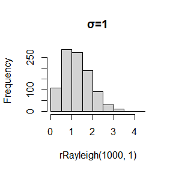

```r
set.seed(0)
rRayleigh <- function(n,sigma)
{
  x <- runif(n)
  r <- sqrt(-2*sigma^2*log(1-x))
  return(r)
}
hist(rRayleigh(1000,1),main = "σ=1")
```

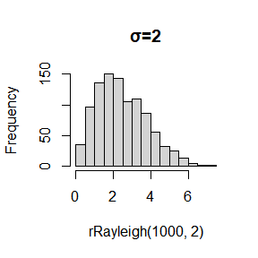

```r
hist(rRayleigh(1000,2),main = "σ=2")
```

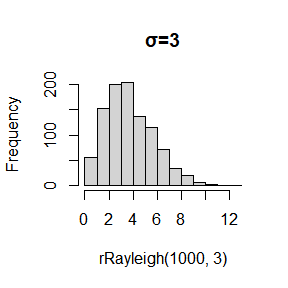

```r
hist(rRayleigh(1000,3),main = "σ=3")
```

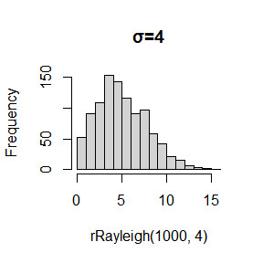

```r
hist(rRayleigh(1000,4),main = "σ=4")
```

## Exercise 3.11

Generate a random sample of size 1000 from a normal location mixture. The components of the mixture have N (0, 1) and N (3, 1) distributions with mixing probabilities p1 and p2 = 1 − p1. Graph the histogram of the sample with density superimposed, for p1 = 0.75. Repeat with different values for p1 and observe whether the empirical distribution of the mixture appears to be bimodal. Make a conjecture about the values of p1 that produce bimodal mixtures.

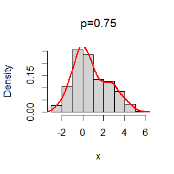

```r
fun <- function(p){
  set.seed(1)
  x1 <- rnorm(1000)
  x2 <- rnorm(1000, 3, 1)
  k <- sample(0:1, size = 1000, replace = TRUE, prob = c(p,1-p))
  x <- (1-k)*x1 + (k)*x2
  hist(x,
       probability = TRUE,
       main = bquote('p='*.(p))
       )
  lines(density(x), lwd = 2, col = "red")
}

fun(0.75)
```

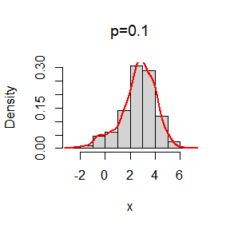

```r
fun(0.1)
```

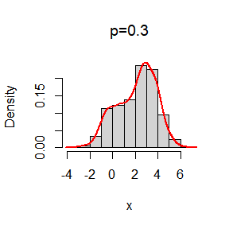

```r
fun(0.3)
```

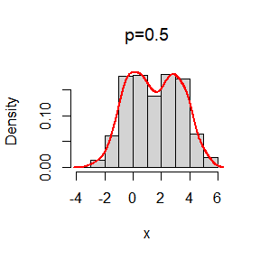

```r
fun(0.5)
```

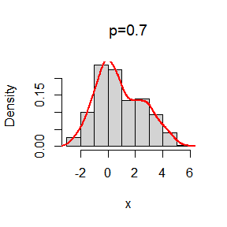

```r
fun(0.7)
```

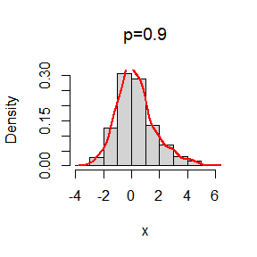

```r
fun(0.9)
```

$p_1$在0.5附近时为双峰，靠近0或1时为单峰